# Ekonometria - projekt

Izabela Reszka, Klaudia Woźniak, Piotr Wiśniewski

07.06.2025

```r
library(dplyr)
library(ggplot2)
library(tidyverse)
library(kableExtra)
library(naniar)
library(scales)
library(e1071)   # dla funkcji skewness
library(tibble)
library(corrplot)
library(tidyr)
library(sf)
library(rnaturalearth)
library(rnaturalearthdata)
library(viridis)
library(spdep)
library(rworldmap)
library(dlookr)
library(readxl)
library(spatialreg)
library(standardize)
```

# 1 1. Cel projektu

Celem projektu jest analiza przestrzennych różnic w statusie społeczno-ekonomicznym uczniów na podstawie przeskalowanych danych z badania PISA. Zostaną zastosowane metody analizy przestrzennej oraz ekonometrii przestrzennej w celu identyfikacji regionalnych nierówności edukacyjnych i ich uwarunkowań społecznych i ekonomicznych. Projekt ma na celu dostarczenie wniosków wspierających decyzje w polityce edukacyjnej i regionalnej.

# 2 Struktura badania

## 2.1 2.1 Sformułowanie problemu badawczego

### 2.1.1 Temat analizy:

**Przestrzenne zróżnicowanie statusu społeczno-ekonomicznego uczniów w krajach uczestniczących w badaniu PISA (2012–2018)**

### 2.1.2 **Problem badawczy:**

Czy status społeczno-ekonomiczny uczniów (mierzony indeksem ESCS) wykazuje istotne różnice przestrzenne pomiędzy krajami uczestniczącymi w badaniu PISA, a jeśli tak – jakie czynniki społeczno-edukacyjne (wykształcenie rodziców, status zawodowy, zasoby w domu) najlepiej te różnice wyjaśniają?

### 2.1.4 **Uzasadnienie wyboru tematu:**

Status społeczno-ekonomiczny uczniów jest silnie powiązany z ich osiągnięciami edukacyjnymi i przyszłymi szansami życiowymi. Analiza jego przestrzennego zróżnicowania pozwala zidentyfikować regiony szczególnie zagrożone nierównościami edukacyjnymi i może wspierać międzynarodowe oraz krajowe polityki wyrównywania szans edukacyjnych.

### 2.1.5 **Poziom przestrzenny analizy:**

Analiza będzie przeprowadzona na poziomie **kraju** (identyfikowanego przez zmienną `cnt`), z uwzględnieniem możliwości rozszerzenia na poziom regionalny (np. NUTS-2), jeśli dane przestrzenne będą dostępne (np. shapefile krajów z granicami administracyjnymi).

# 3 Opis danych

Dane pochodzą z międzynarodowego badania edukacyjnego PISA, obejmującego uczniów z różnych krajów i lat. Obejmują 1 447 787 obserwacji z ponad 70 krajów w trzech cyklach badania (2012, 2015, 2018). W analizie wykorzystano zarówno cechy indywidualne uczniów, jak i dane identyfikujące kraj, szkołę i przynależność do OECD.

### 3.0.1 **Struktura danych:**

| Zmienna | Opis |
| --- | --- |
| **cycnt** | Unikalny identyfikator kraju i cyklu (np. `05POL` = Polska 2012). |
| **cycle** | Rok badania PISA (5 = 2012, 6 = 2015, 7 = 2018). |
| **cnt** | Kod kraju trzyliterowy (np. `POL`, `DEU`, `USA`). |
| **schoolid** | ID szkoły (unikalne w obrębie danego kraju i cyklu). |
| **studentid** | ID ucznia (unikalne w obrębie szkoły i cyklu). |
| **oecd** | Przynależność kraju do OECD (`1` = tak, `0` = nie). |
| **escs_trend** | Indeks statusu społeczno-ekonomicznego ucznia (ESCS, standaryzowany). |
| **hisei_trend** | Indeks najwyższego statusu zawodowego rodzica (HISEI). |
| **homepos_trend** | Indeks wyposażenia domu w zasoby edukacyjne (HOMEPOS). |
| **paredint_trend** | Poziom wykształcenia rodziców (PAREDINT, wg skali ISCED). |

### 3.0.2 **Charakterystyka danych:**

- **Liczba krajów:** 73 (np. POL, DEU, FRA, JPN, USA, BRA, QAT…)
- **Lata pomiarów:** 2012, 2015, 2018 (zakodowane jako 5, 6, 7)
- **Kraje OECD:** rozróżnienie na kraje OECD (`1`) i nie-OECD (`0`)
- **Zakres zmiennych społeczno-ekonomicznych:** zmienne `escs_trend`, `hisei_trend`, `homepos_trend` i `paredint_trend` opisują status ucznia w ujęciu międzynarodowym, w sposób porównywalny między cyklami.

# 4 Identyfikacja braków danych i obserwacji odstających

## 4.1 Braki danych

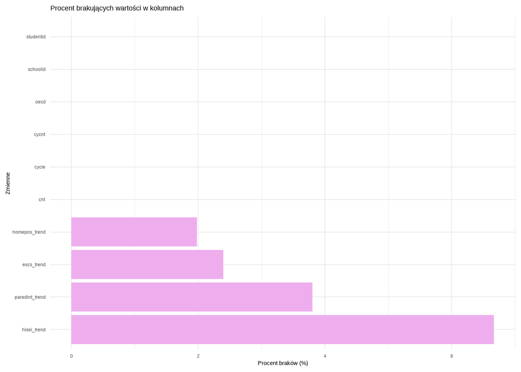

Podsumowanie brakujących danych

| Zmienna | Liczba braków | Procent braków | Zmienna | Liczba braków | Procent braków |
| --- | --- | --- | --- | --- | --- |
| hisei_trend | 96525 | 6.7% | cycle | 0 | 0.0% |
| paredint_trend | 55081 | 3.8% | cnt | 0 | 0.0% |
| escs_trend | 34731 | 2.4% | schoolid | 0 | 0.0% |
| homepos_trend | 28662 | 2.0% | studentid | 0 | 0.0% |
| cycnt | 0 | 0.0% | oecd | 0 | 0.0% |

Wykres słupkowy przedstawia procent brakujących danych dla każdej zmiennej w zbiorze. Największy odsetek braków występuje w zmiennej:

- hisei_trend (6,7% braków), następnie w:
- paredint_trend (3,8% braków),
- escs_trend (2,4% braków),
- homepos_trend (2,0% braków).
- Dla zmiennych identyfikacyjnych (cycnt, cycle, cnt, schoolid, studentid, oecd) nie odnotowano braków.

Braki danych są obecne głównie w zmiennych objaśniających związanych ze statusem społeczno-ekonomicznym, ale ich skala nie przekracza 7%, co pozwala na bezpieczne przeprowadzenie analiz po ewentualnym zastosowaniu imputacji lub usunięciu niekompletnych rekordów.

## 4.2 Odstające

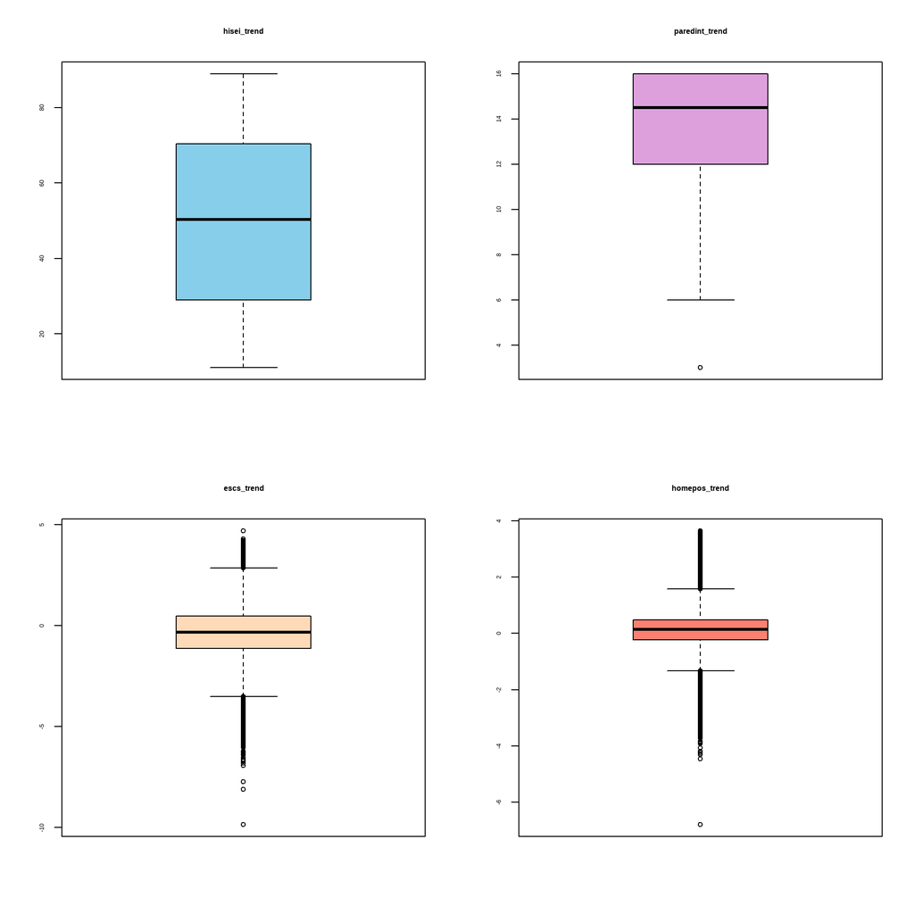

Przedstawiono wykresy pudełkowe dla kluczowych zmiennych ilościowych, umożliwiające identyfikację obserwacji odstających:

1. hisei_trend: Rozkład wyników jest stosunkowo symetryczny. Nie są widoczne obserwacje odstające co w sumie ma sens bo to określa status zawodowy rodzica.
2. paredint_trend: Rozkład ma niewielką liczbę obserwacji odstających, głównie na dolnym końcu skali (niskie poziomy wykształcenia rodziców).
3. escs_trend: Rozkład statusu społeczno-ekonomicznego jest względnie symetryczny, jednak posiada odstające wartości, głównie po stronie negatywnej (niski status społeczno-ekonomiczny).
4. homepos_trend: Występuje większa liczba obserwacji odstających zarówno poniżej, jak i powyżej głównego rozkładu, co może wskazywać na zróżnicowane wyposażenie domów uczniów w zasoby edukacyjne.

Obserwacje odstające są obecne, ale nie są ekstremalne. W zależności od dalszych analiz, można je uwzględnić lub rozważyć ich ograniczoną korektę.

# 5 Obliczenie podstawowych statystyk opisowych (m.in. średnia, mediana, min, max, odchylenie standardowe, współczynniki asymetrii)

Statystyki opisowe

| Zmienna | Mediana | Srednia | Min | Max | Odchylenie_std | Asymetria |
| --- | --- | --- | --- | --- | --- | --- |
| escs_trend | -0.320500 | -0.4049415 | -9.861800 | 4.703700 | 1.1281890 | -0.4914098 |
| hisei_trend | 50.369999 | 49.4372611 | 11.010000 | 88.959999 | 21.8505228 | 0.0533873 |
| homepos_trend | 0.148944 | 0.1143127 | -6.801333 | 3.649307 | 0.5931938 | -0.2246445 |
| paredint_trend | 14.500000 | 13.2444061 | 3.000000 | 16.000000 | 2.9939620 | -1.1750651 |

Dla zmiennej escs_trend (trend statusu społeczno-ekonomicznego uczniów), średnia wynosi ok. -0.40, a mediana -0.32, co sugeruje, że wartości są lekko przesunięte w lewo (potwierdza to też ujemna asymetria: -0.49). Rozstęp wyników jest szeroki – od ok. -9.86 do 4.70, a odchylenie standardowe to 1.13, co wskazuje na umiarkowane zróżnicowanie.

W przypadku hisei_trend (trend prestiżu zawodowego rodziców), średnia to 49.4, zbliżona do mediany (50.37), co świadczy o symetrycznym rozkładzie (asymetria bliska zeru). Wartości mieszczą się w zakresie od 11 do ok. 89, a odchylenie standardowe (21.85) pokazuje dość dużą zmienność.

Dla homepos_trend (trend zasobów domowych), wartości wahają się od -6.80 do 3.65, przy średniej 0.11 i medianie 0.15. Rozkład jest lekko lewostronny (asymetria: -0.22), a zróżnicowanie niskie (odchylenie: 0.59).

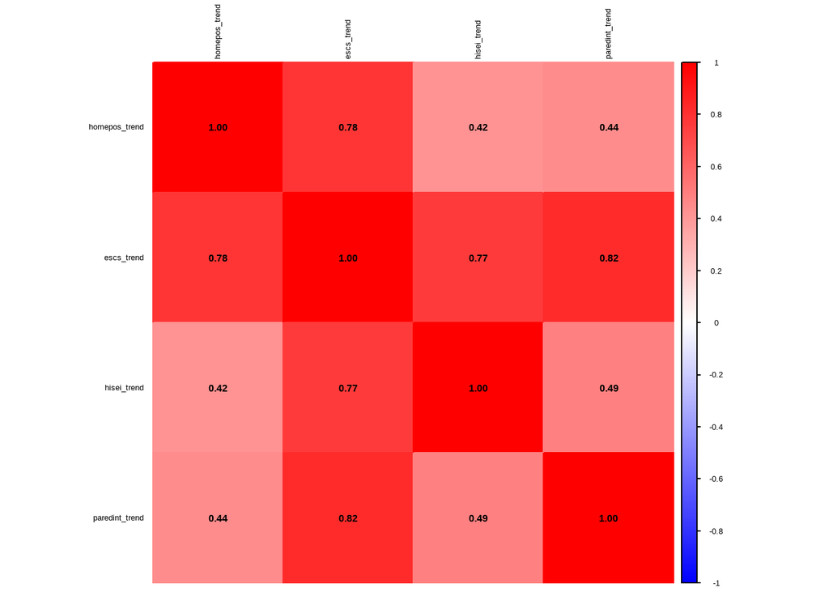

1. escs_trend jest silnie dodatnio skorelowany z:
- homepos_trend (r = 0,78),
- hisei_trend (r = 0,77),
- paredint_trend (r = 0,82).
2. homepos_trend i hisei_trend są umiarkowanie skorelowane (r = 0,42),
3. homepos_trend i paredint_trend również wykazują umiarkowaną korelację (r = 0,44),
4. hisei_trend i paredint_trend mają średnio silną korelację (r = 049).

Zmienna escs_trend silnie powiązana jest zarówno z wyposażeniem domu (homepos_trend), statusem zawodowym rodziców (hisei_trend), jak i ich wykształceniem (paredint_trend), co potwierdza, że ESCS dobrze syntetyzuje te aspekty społeczno-ekonomiczne.

# 6 Wykresy: histogramy, wykresy rozrzutu, gęstości

## 6.1 Wykresy gęstości

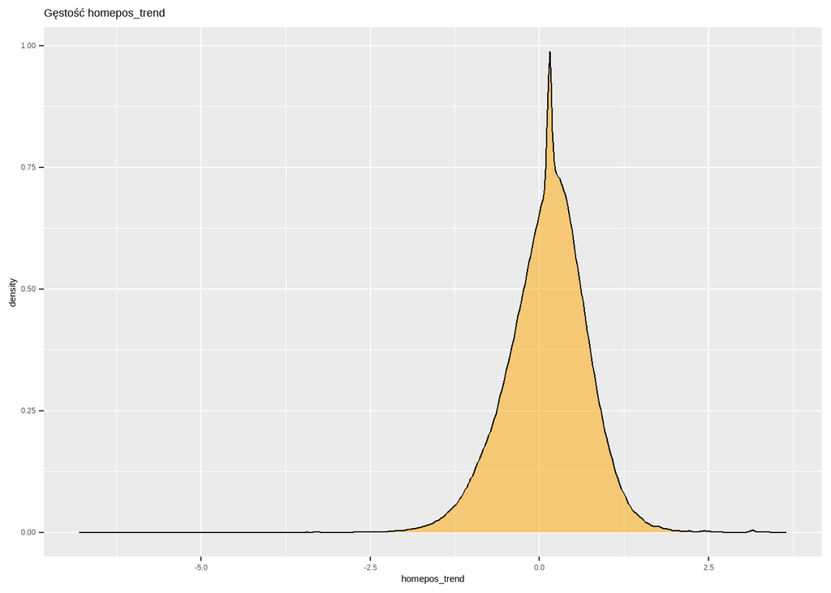

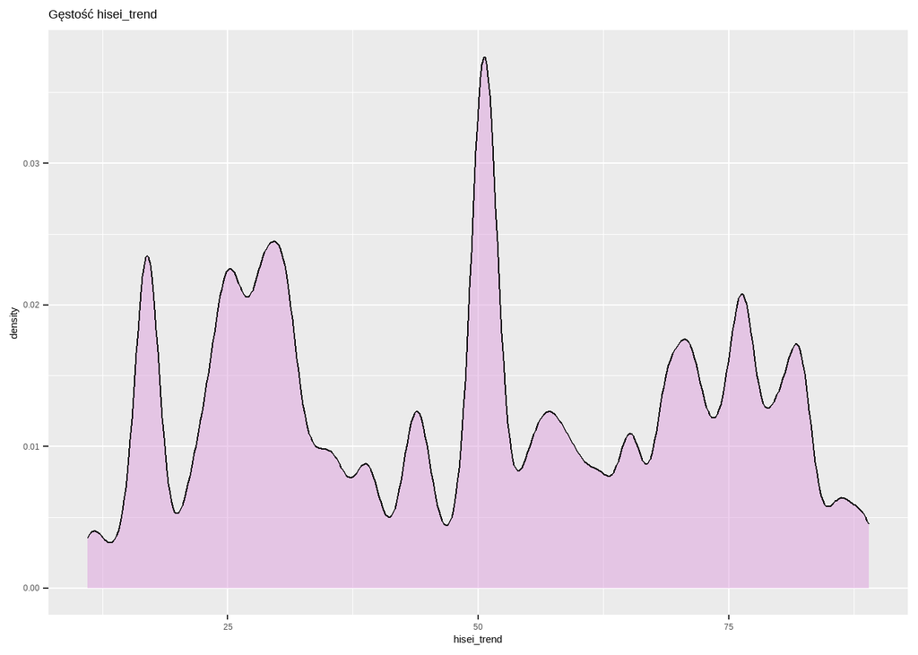

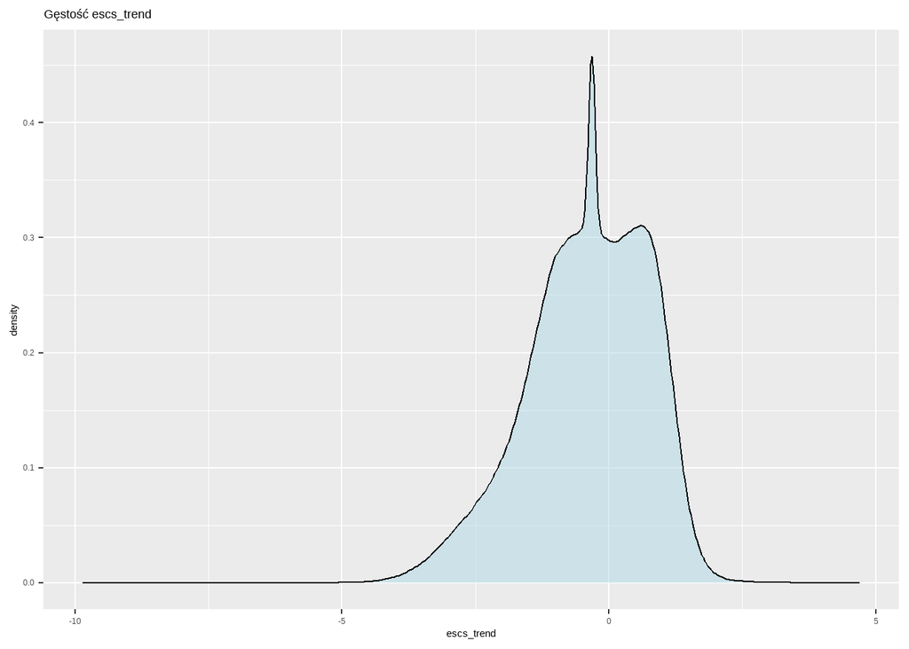

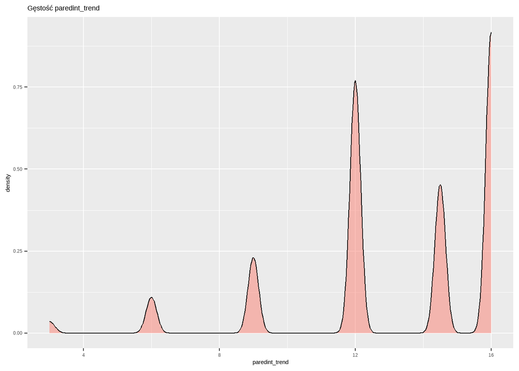

## 6.2 Histogramy

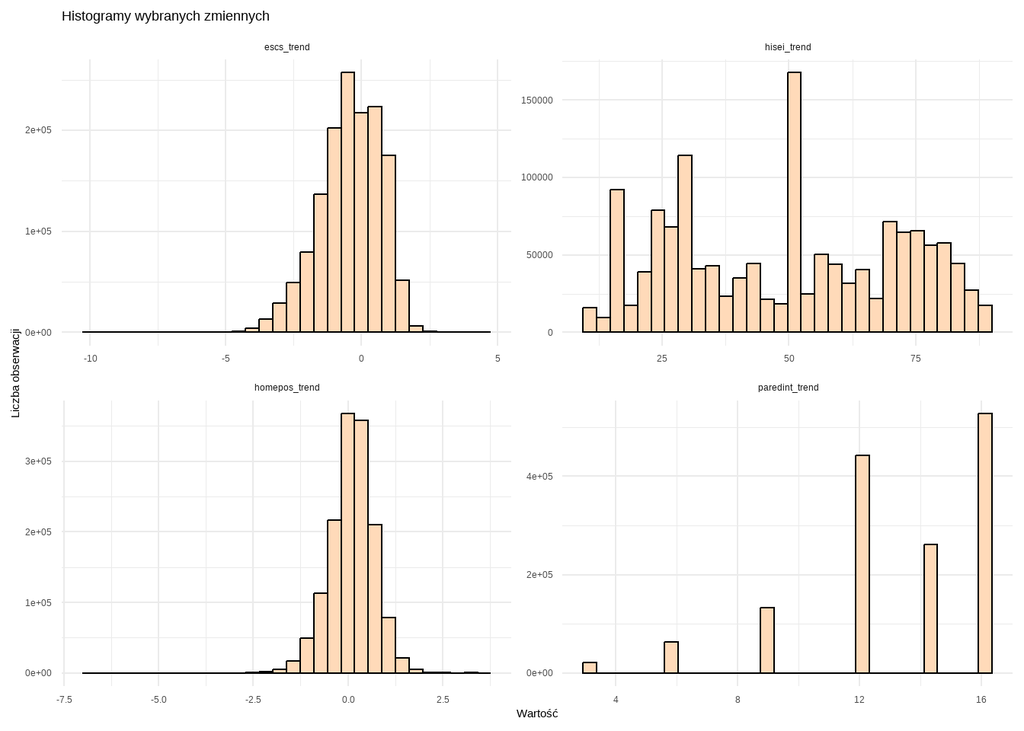

Histogram zmiennej escs_trend, czyli ogólnego wskaźnika statusu społeczno-ekonomicznego uczniów, przedstawia rozkład zbliżony do normalnego, z lekką skośnością. Większość obserwacji koncentruje się wokół wartości bliskich zeru, co sugeruje, że przeważają uczniowie o przeciętnym statusie społeczno-ekonomicznym. Ekstremalnie niskie lub wysokie wartości są stosunkowo rzadkie, co może świadczyć o względnym wyrównaniu warunków społecznych wśród badanych uczniów.

Zmienna hisei_trend, odzwierciedlająca status zawodowy rodziców, ma wielomodalny rozkład (rozkład, który ma więcej niż jedno maksimum (szczyt) w wykresie), co oznacza obecność kilku wyraźnych szczytów. Wskazuje to na istnienie kilku dominujących grup zawodowych, takich jak np. robotnicy, specjaliści czy menedżerowie. Takie zróżnicowanie sugeruje dużą różnorodność środowisk zawodowych, z jakich pochodzą uczniowie, oraz możliwe wpływy struktury rynku pracy w poszczególnych krajach.

Rozkład zmiennej homepos_trend, opisującej zasoby edukacyjne w domu (np. liczba książek, komputery, biurko), również zbliżony jest do rozkładu normalnego, z lekkim przechyleniem. Najwięcej uczniów ma dostęp do umiarkowanych lub przeciętnych zasobów edukacyjnych, natomiast skrajnie niskie zasoby występują rzadziej. Wskazuje to na pewien stopień wyrównania dostępu do podstawowych narzędzi wspierających edukację.

## 6.3 Wykresy rozrzutu

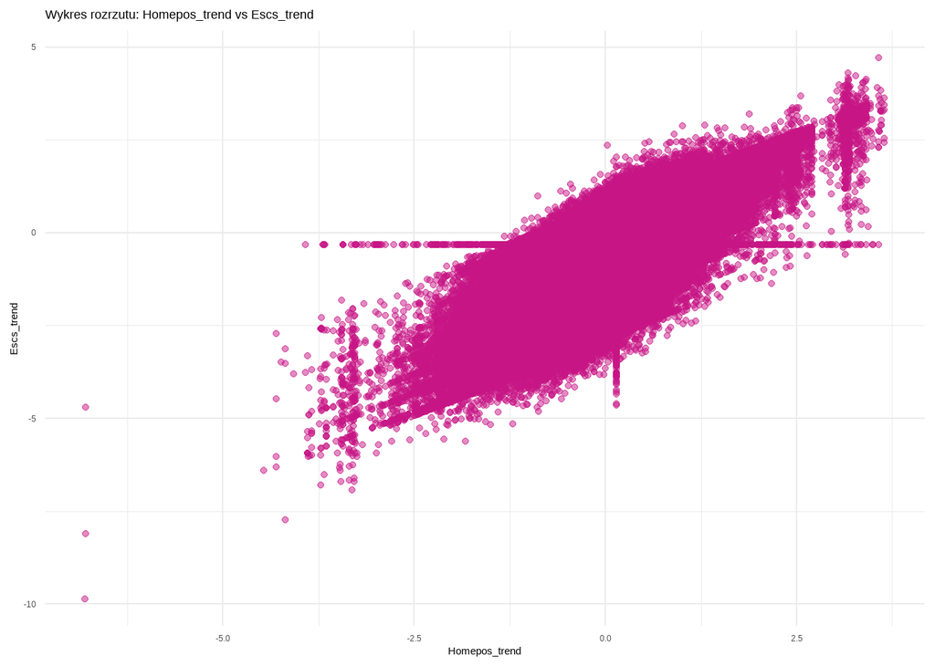

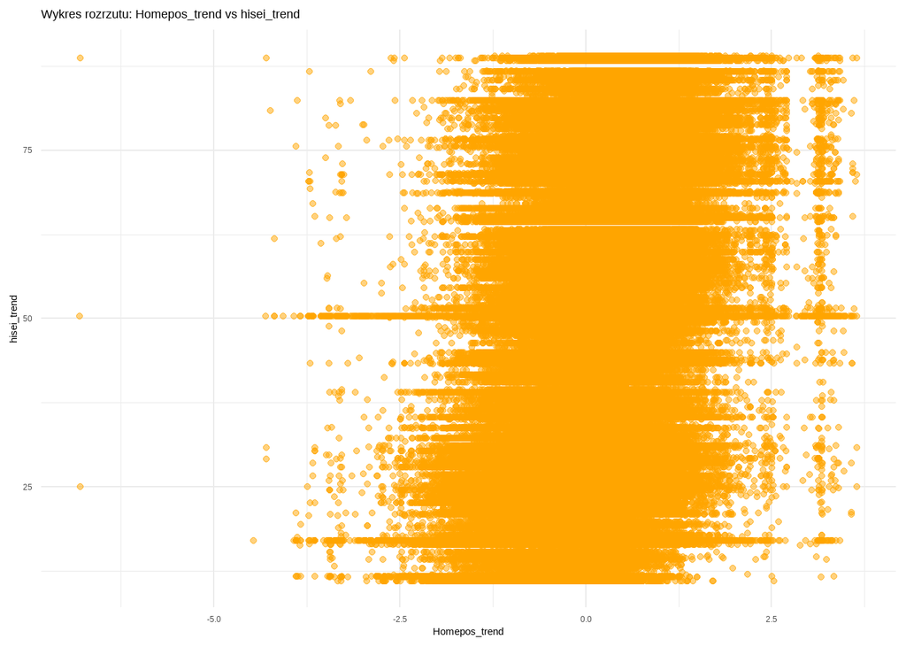

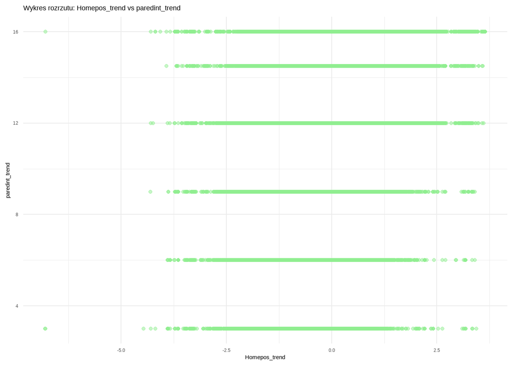

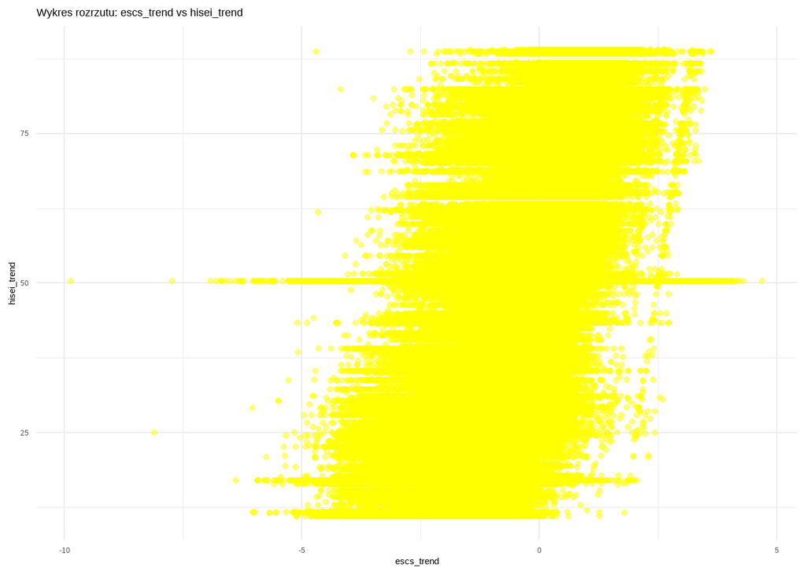

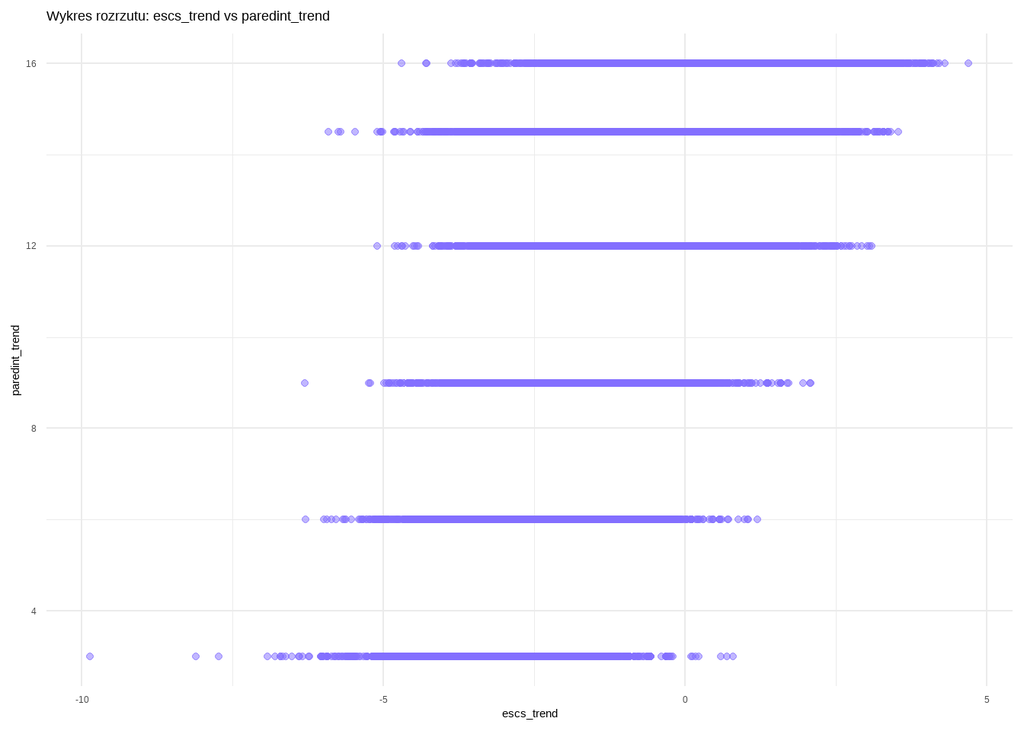

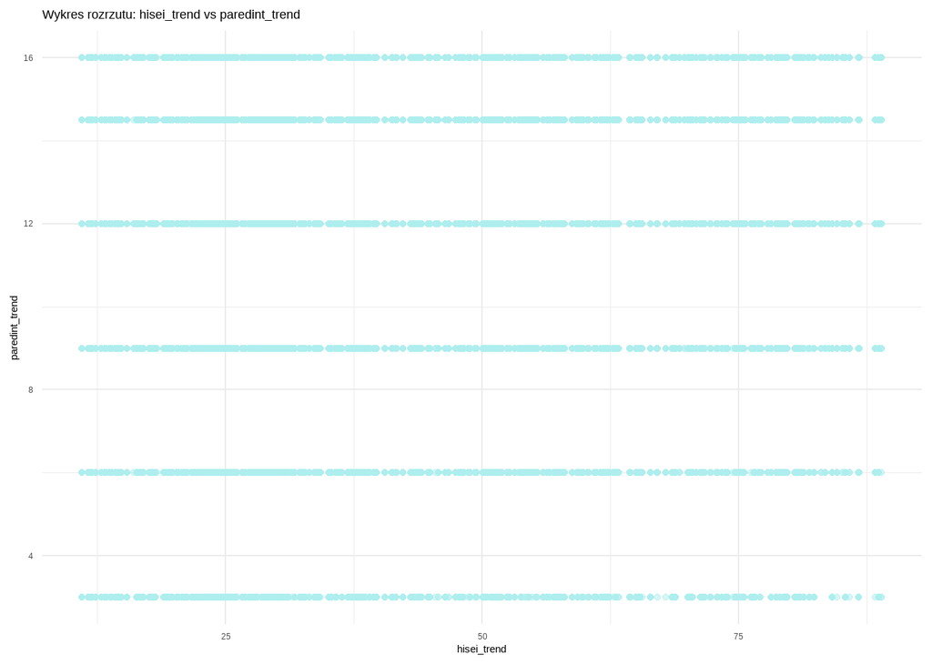

# 7 Proste mapy (kartogramy) rozkładu dla zmiennej zależnej i wybranych zmiennych objaśniających.

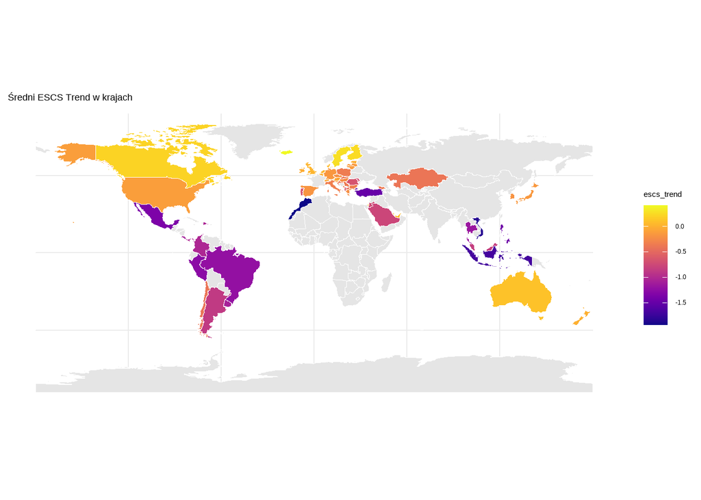

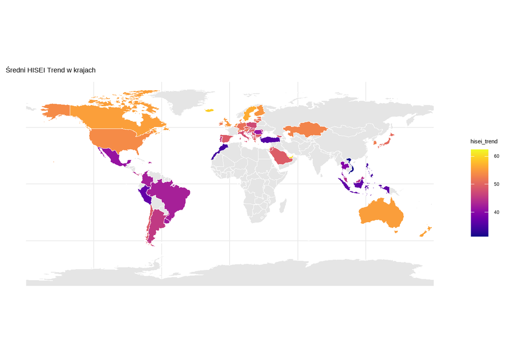

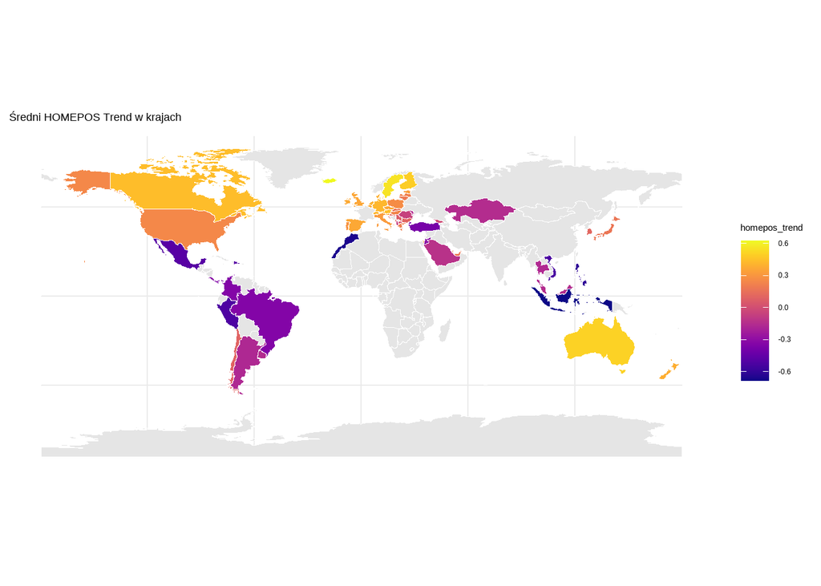

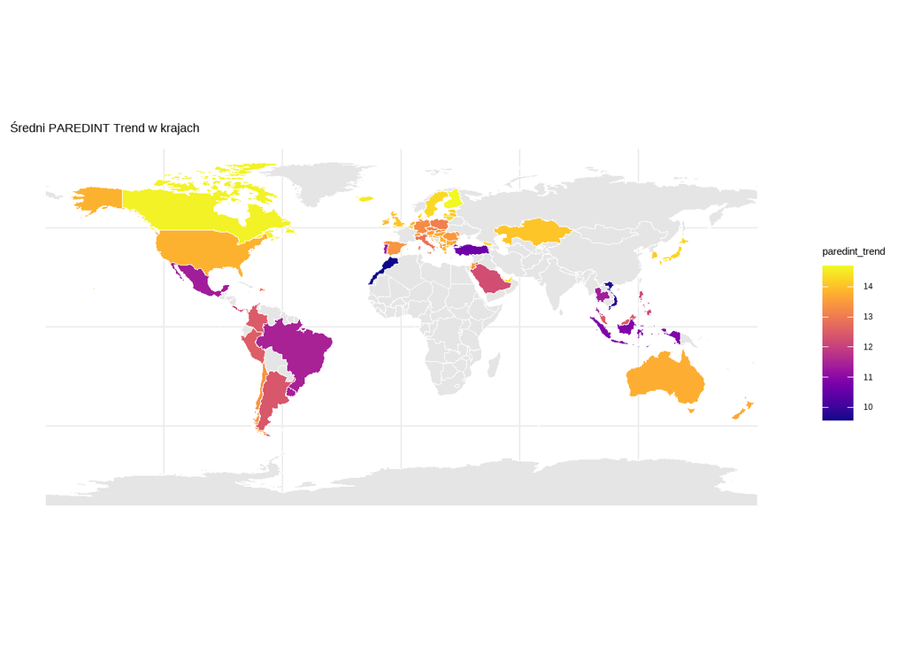

Średni ESCS Trend w krajach

Mapa przedstawia przestrzenne zróżnicowanie średniego trendowego indeksu statusu społeczno-ekonomicznego uczniów (ESCS) w poszczególnych krajach uczestniczących w badaniu PISA. Wartości dodatnie (w odcieniach żółci i pomarańczu) oznaczają kraje, w których uczniowie mają wyższy status społeczno-ekonomiczny niż średnia OECD. Z kolei wartości ujemne (w odcieniach fioletu i granatu) wskazują na niższy status społeczno-ekonomiczny. Mapa pokazuje wyraźne zróżnicowanie pomiędzy regionami — wyższe wartości dominują w Europie Północnej, Kanadzie i Australii, natomiast niższe widoczne są m.in. w Ameryce Południowej, Maroko, Arabia Saudyjska. Zróżnicowanie indeksu ESCS może odzwierciedlać poziom rozwoju społeczno-gospodarczego i dostęp uczniów do zasobów edukacyjnych. Może to mieć istotne znaczenie dla planowania polityk edukacyjnych i społecznych w danym kraju.

Średni HISEI Trend w krajach

Mapa pokazuje średnią wartość trendowego indeksu HISEI w krajach objętych badaniem PISA. HISEI odzwierciedla najwyższy status zawodowy rodzica ucznia. Im wyższy wynik, tym bardziej prestiżowy zawód zajmuje przynajmniej jeden z rodziców. W krajach rozwiniętych, takich jak Kanada, Australia czy kraje skandynawskie, wartości HISEI są wyższe, co może świadczyć o wyższym prestiżu zawodowym rodziców uczniów. Niższe wartości w niektórych krajach Ameryki Południowej (np Brazylia), Europy Południowo-Wschodniej mogą wskazywać na ograniczony dostęp do zawodów o wyższym statusie społecznym.

Średni HOMEPOS Trend w krajach

Wykres przedstawia średni poziom zasobów edukacyjnych w domach uczniów (indeks homepos_trend) w różnych krajach uczestniczących w badaniu PISA. Wysokie wartości (żółte i pomarańczowe odcienie) wskazują na lepsze wyposażenie domów w środki wspierające naukę, takie jak książki, biurka, komputery czy internet. Niskie wartości (fioletowe i niebieskie odcienie) sugerują niedobór tych zasobów. Można zauważyć wyraźne różnice między krajami rozwiniętymi a rozwijającymi się – np. wysoki poziom zasobów w krajach skandynawskich, Kanadzie i Australii vs. niski poziom w Ameryce Południowej i niektórych krajach Azji.

Średni PAREDINT Trend w krajach Wykres ilustruje średni poziom wykształcenia rodziców uczniów (paredint_trend) w poszczególnych krajach, oparty na skali międzynarodowej (ISCED). Wyższe wartości (żółto-pomarańczowe odcienie) oznaczają wyższy przeciętny poziom wykształcenia rodziców, np. wykształcenie wyższe. Niższe wartości (fioletowe odcienie) sugerują, że dominujące jest wykształcenie średnie lub podstawowe. Wysoki poziom można zaobserwować m.in. w krajach Europy, Kanadzie, Australii, natomiast niski – w wielu państwach Ameryki Południowej, Arabii Saudyjskiej.

ESCS dobrze oddaje ogólny poziom, ale analiza komponentów (HISEI, HOMEPOS, PAREDINT) pozwala lepiej zrozumieć źródła różnic między krajami.

# 8 Wspolczynnik Moran

```
##
##  Moran I test under randomisation
##
## data:  merged_data$escs_trend
## weights: lw
##
## Moran I statistic standard deviate = 3.9084, p-value = 4.645e-05
## alternative hypothesis: greater
## sample estimates:
## Moran I statistic       Expectation          Variance
##       0.326167211      -0.014925373       0.007616173
```

Wartość statystyki Moran’s I = 0.326 Kraje o podobnych wartościach escs_trend (statusie społeczno-ekonomicznym uczniów) grupują się blisko siebie. Np: Jeśli Polska ma wysokie escs_trend, to jej sąsiedzi (Niemcy, Czechy) też prawdopodobnie mają wysokie wartości.

p-value = 4.645e-05 (<< 0.05) Wynik jest wysoce istotny statystycznie – odrzucamy hipotezę zerową o braku autokorelacji przestrzennej. Możemy zatem rozważać modele przestrzenne.

Standard deviate = 3.9084 Wartość statystyki jest prawie 4 odchylenia standardowe powyżej oczekiwań (Expectation = -0.015), co potwierdza silny wzorzec przestrzenny.

Status społeczno-ekonomiczny uczniów nie jest rozłożony losowo – istnieją wyraźne regionalne wzorce.

Możemy zobaczy czy klastry pokrywają się z podziałem na kraje OECD np zy kraje OECD mają wyższe escs_trend i grupują się razem.obliczenie lokalnego moran’a (LISA)

# 9 Wspolczynnik LISA

```
##
##            HH or LL Outlier
##   non-OECD        5       0
##   OECD            3       1
```

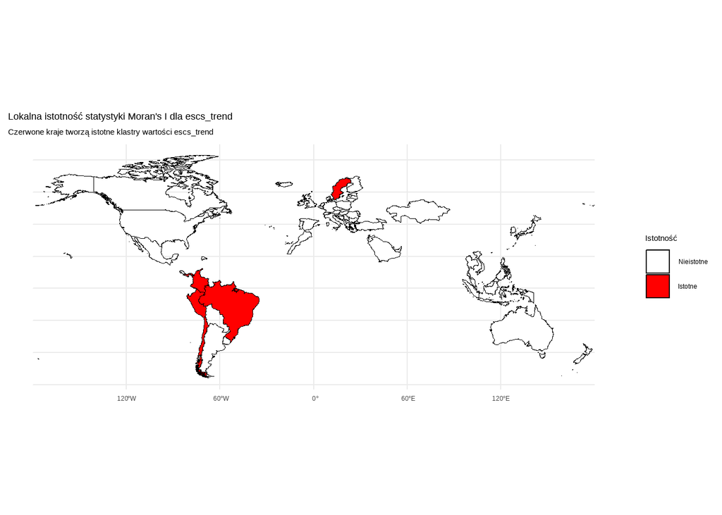

Czerwonym kolorem na mapie oznaczono kraje, dla których stwierdzono istotną wartość lokalnej statystyki Morana oznacza to, że kraje te otoczone są krajami o podobnej wartości analizowanego zjawiska

# 10 Estymacja klasycznego modelu OLS

```
##
## Call:
## lm(formula = escs_trend ~ hisei_trend + homepos_trend + paredint_trend,
##     data = dane)
##
## Residuals:
##      Min       1Q   Median       3Q      Max
## -2.99693  0.00241  0.00901  0.01672  3.12532
##
## Coefficients:
##                  Estimate Std. Error t value Pr(>|t|)
## (Intercept)    -3.695e+00  5.355e-04   -6899   <2e-16 ***
## hisei_trend     1.880e-02  5.870e-06    3204   <2e-16 ***
## homepos_trend   8.111e-01  2.095e-04    3872   <2e-16 ***
## paredint_trend  1.712e-01  4.320e-05    3963   <2e-16 ***
## ---
## Signif. codes:  0 '***' 0.001 '**' 0.01 '*' 0.05 '.' 0.1 ' ' 1
##
## Residual standard error: 0.1294 on 1447783 degrees of freedom
## Multiple R-squared:  0.9868, Adjusted R-squared:  0.9868
## F-statistic: 3.62e+07 on 3 and 1447783 DF,  p-value: < 2.2e-16
```

```
## Start:  AIC=-5920811
## escs_trend ~ hisei_trend + homepos_trend + paredint_trend
##
##                  Df Sum of Sq    RSS      AIC
## <none>                         24245 -5920811
## - hisei_trend     1    171884 196129 -2894145
## - homepos_trend   1    251089 275335 -2403037
## - paredint_trend  1    262979 287225 -2341829
```

```
##
## Call:
## lm(formula = escs_trend ~ hisei_trend + homepos_trend + paredint_trend,
##     data = dane)
##
## Residuals:
##      Min       1Q   Median       3Q      Max
## -2.99693  0.00241  0.00901  0.01672  3.12532
##
## Coefficients:
##                  Estimate Std. Error t value Pr(>|t|)
## (Intercept)    -3.695e+00  5.355e-04   -6899   <2e-16 ***
## hisei_trend     1.880e-02  5.870e-06    3204   <2e-16 ***
## homepos_trend   8.111e-01  2.095e-04    3872   <2e-16 ***
## paredint_trend  1.712e-01  4.320e-05    3963   <2e-16 ***
## ---
## Signif. codes:  0 '***' 0.001 '**' 0.01 '*' 0.05 '.' 0.1 ' ' 1
##
## Residual standard error: 0.1294 on 1447783 degrees of freedom
## Multiple R-squared:  0.9868, Adjusted R-squared:  0.9868
## F-statistic: 3.62e+07 on 3 and 1447783 DF,  p-value: < 2.2e-16
```

W celu zbadania, które czynniki mają wpływ na trend zmiennej zależnej **escs_trend** (wskaźnika społeczno-ekonomicznego uczniów), przeprowadzono analizę regresji liniowej, w której jako zmienne niezależne uwzględniono:

Wszystkie trzy zmienne niezależne okazały się statystycznie istotne na poziomie istotności p < 0,001.

Model również wykazał bardzo wysokie dopasowanie do danych: - **R² = 0,9868**, co oznacza, że aż 98,68% zmienności wskaźnika escs_trend można wyjaśnić za pomocą zastosowanych zmiennych niezależnych. - **Statystyka F= 3.62e+07** przy p < 2,2e-16 potwierdza, że model jako całość jest statystycznie istotny.

Analiza kryterium (AIC) wskazuje, że usunięcie którejkolwiek ze zmiennych sktutkuje znacznym pogorszeniem dopasowania modelu (istotny wzrost RSS i AIC), co oznacza, że każda z uwzględnionych zmiennych wnosi istotną wartość informacyjną.

# 11 Model SAR i SEM & porównanie modeli // ponowne OLS i test Morana

```
##
## Call:
## lm(formula = escs_trend ~ hisei_trend + homepos_trend + paredint_trend,
##     data = merged_data)
##
## Residuals:
##       Min        1Q    Median        3Q       Max
## -0.082088 -0.001899  0.002319  0.005426  0.019665
##
## Coefficients:
##                  Estimate Std. Error t value Pr(>|t|)
## (Intercept)    -3.7273807  0.0270047 -138.03   <2e-16 ***
## hisei_trend     0.0196393  0.0005414   36.27   <2e-16 ***
## homepos_trend   0.7907551  0.0086503   91.41   <2e-16 ***
## paredint_trend  0.1706799  0.0024317   70.19   <2e-16 ***
## ---
## Signif. codes:  0 '***' 0.001 '**' 0.01 '*' 0.05 '.' 0.1 ' ' 1
##
## Residual standard error: 0.01336 on 64 degrees of freedom
## Multiple R-squared:  0.9994, Adjusted R-squared:  0.9994
## F-statistic: 3.792e+04 on 3 and 64 DF,  p-value: < 2.2e-16
```

```
##
##  Moran I test under randomisation
##
## data:  residuals(ols_model)
## weights: lw
##
## Moran I statistic standard deviate = -0.50929, p-value = 0.6947
## alternative hypothesis: greater
## sample estimates:
## Moran I statistic       Expectation          Variance
##      -0.050830249      -0.014925373       0.004970176
```

```
##
## Call:lagsarlm(formula = escs_trend ~ hisei_trend + homepos_trend +
##     paredint_trend, data = merged_data, listw = lw, method = "eigen",
##     zero.policy = TRUE)
##
## Residuals:
##        Min         1Q     Median         3Q        Max
## -0.0818423 -0.0018281  0.0022656  0.0057331  0.0196876
##
## Type: lag
## Coefficients: (asymptotic standard errors)
##                   Estimate  Std. Error  z value  Pr(>|z|)
## (Intercept)    -3.72845815  0.02666440 -139.829 < 2.2e-16
## hisei_trend     0.01961661  0.00053639   36.571 < 2.2e-16
## homepos_trend   0.79133794  0.00883605   89.558 < 2.2e-16
## paredint_trend  0.17080349  0.00243038   70.279 < 2.2e-16
##
## Rho: -0.00098957, LR test value: 0.045267, p-value: 0.83151
## Asymptotic standard error: 0.0046447
##     z-value: -0.21305, p-value: 0.83129
## Wald statistic: 0.045391, p-value: 0.83129
##
## Log likelihood: 199.0384 for lag model
## ML residual variance (sigma squared): 0.00016793, (sigma: 0.012959)
## Number of observations: 68
## Number of parameters estimated: 6
## AIC: -386.08, (AIC for lm: -388.03)
## LM test for residual autocorrelation
## test value: 0.31686, p-value: 0.5735
```

```
##
## Call:errorsarlm(formula = escs_trend ~ hisei_trend + homepos_trend +
##     paredint_trend, data = merged_data, listw = lw, method = "eigen",
##     zero.policy = TRUE)
##
## Residuals:
##        Min         1Q     Median         3Q        Max
## -0.0819406 -0.0016902  0.0023606  0.0054801  0.0192883
##
## Type: error
## Coefficients: (asymptotic standard errors)
##                   Estimate  Std. Error  z value  Pr(>|z|)
## (Intercept)    -3.72885983  0.02526776 -147.574 < 2.2e-16
## hisei_trend     0.01972095  0.00050622   38.957 < 2.2e-16
## homepos_trend   0.78963408  0.00795335   99.283 < 2.2e-16
## paredint_trend  0.17049578  0.00230542   73.954 < 2.2e-16
##
## Lambda: -0.083444, LR test value: 0.28818, p-value: 0.59139
## Asymptotic standard error: 0.16812
##     z-value: -0.49634, p-value: 0.61965
## Wald statistic: 0.24635, p-value: 0.61965
##
## Log likelihood: 199.1599 for error model
## ML residual variance (sigma squared): 0.00016708, (sigma: 0.012926)
## Number of observations: 68
## Number of parameters estimated: 6
## AIC: -386.32, (AIC for lm: -388.03)
```

```
##           df       AIC
## ols_model  5 -388.0316
## sar_model  6 -386.0769
## sem_model  6 -386.3198
```

Model OLS został ponownie oszacowany na tym samym zestawie danych, co modele przestrzenne, aby umożliwić bezpośrednie porównanie ich dopasowania (AIC) i zapewnić porównywalność wyników.

Model klasyczny (OLS) wykazał, że wszystkie trzy zmienne objaśniające miały pozytywny i statystycznie istotny wpływ na **escs_trend**, co oznacza, że wyższy status zawodowy rodziców **(hisei_trend)**, lepsze zasoby edukacyjne w domu **(homepos_trend)** oraz wyższy poziom wykształcenia rodziców **(paredint_trend)** wiążą się z wyższym statusem społeczno-ekonomicznym uczniów. Model cechował się bardzo wysokim dopasowaniem **(R² = 0.9994)**, co sugeruje niemal pełne wyjaśnienie zmienności zmiennej zależnej.

Test Morana dla reszt modelu OLS (I = -0.05, p = 0.69) nie wykazał istotnej autokorelacji przestrzennej. Oznacza to, że reszty modelu są niezależne przestrzennie, a więc nie ma formalnej konieczności stosowania modeli przestrzennych.

Niemniej jednak, oszacowano również modele SAR (z opóźnieniem przestrzennym) i SEM (z błędem przestrzennym) w celu weryfikacji, czy uwzględnienie komponentów przestrzennych wpłynie na dopasowanie modelu. W obu przypadkach współczynniki przestrzenne okazały się statystycznie nieistotne:

- **SAR**: rho = -0.001, p = 0.83
- **SEM**: lambda = -0.083, p = 0.62

Co więcej, porównanie wartości AIC wykazało, że model OLS (AIC = -388.03) miał lepsze dopasowanie niż modele SAR (AIC = -386.08) i SEM (AIC = -386.32).

Ostatecznie, modele przestrzenne nie wniosły dodatkowej wartości względem klasycznego OLS, a zależności między krajami w kontekście zmiennej **escs_trend** można wyjaśnić bez potrzeby uwzględniania efektów przestrzennych.

# 12 Model Durbina

```
##
## Call:lagsarlm(formula = escs_trend ~ hisei_trend + homepos_trend +
##     paredint_trend, data = merged_data, listw = lw, type = "mixed",
##     method = "eigen", zero.policy = TRUE)
##
## Residuals:
##        Min         1Q     Median         3Q        Max
## -0.0785269 -0.0015013  0.0024483  0.0051416  0.0183909
##
## Type: mixed
## Coefficients: (asymptotic standard errors)
##                       Estimate  Std. Error z value  Pr(>|z|)
## (Intercept)        -4.06152053  0.62642477 -6.4837 8.953e-11
## hisei_trend         0.01910683  0.00066569 28.7021 < 2.2e-16
## homepos_trend       0.80229238  0.01222482 65.6281 < 2.2e-16
## paredint_trend      0.17086185  0.00251929 67.8215 < 2.2e-16
## lag.hisei_trend     0.00288492  0.00341768  0.8441    0.3986
## lag.homepos_trend   0.05054162  0.13323300  0.3793    0.7044
## lag.paredint_trend  0.01309156  0.02880612  0.4545    0.6495
##
## Rho: -0.086106, LR test value: 0.31826, p-value: 0.57266
## Asymptotic standard error: 0.16751
##     z-value: -0.51403, p-value: 0.60723
## Wald statistic: 0.26423, p-value: 0.60723
##
## Log likelihood: 200.1457 for mixed model
## ML residual variance (sigma squared): 0.00016229, (sigma: 0.012739)
## Number of observations: 68
## Number of parameters estimated: 9
## AIC: -382.29, (AIC for lm: -383.97)
## LM test for residual autocorrelation
## test value: 0.28532, p-value: 0.59323
```

Model Durbin (SDM) został wykorzystany jako rozszerzenie modelu SAR. Uwzględnia on nie tylko wpływ przestrzennego opóźnienia zmiennej zależnej, ale też sprawdza, czy wartości zmiennych objaśniających w sąsiednich krajach mają znaczenie dla poziomu **escs_trend**.

Wyniki pokazały, że wszystkie lokalne zmienne – **hisei_trend** (β = 0.0191), **homepos_trend** (β = 0.8023) i **paredint_trend** (β = 0.1709) – miały pozytywny i istotny wpływ na **escs_trend** (p < 0.001). Z kolei ich przestrzenne odpowiedniki, np. **lag.homepos_trend** (β = 0.0505, p = 0.70), nie były istotne statystycznie. To znaczy, że sytuacja w krajach sąsiednich raczej nie wpływa na poziom ESCS.

Także współczynnik rho, który mierzy przestrzenne zależności w zmiennej zależnej, nie był istotny (rho = -0.086, p = 0.61).

Model Durbin miał wyższy AIC (-382.29) niż klasyczny model OLS (-388.03), co oznacza, że był trochę gorzej dopasowany.

Nie znaleziono zatem dowodów na to, że czynniki przestrzenne wpływają na poziom **escs_trend**. Lepiej sprawdza się zwykła regresja, oparta tylko na lokalnych danych z danego kraju.

# 13 Wnioski i rekomendacje

## 13.1 1. Kluczowe czynniki wpływające na **ESCS Trend**

| Zmienna (skala) | Współczynnik (OLS) | Interpretacja |
| --- | --- | --- |
| **homepos_trend** (≈ –1 ÷ +3) | +0.79 | Najsilniejszy efekt: wzrost o 1 pkt w indeksie zasobów domowych podnosi średni ESCS o ~0,8 pkt. To sugeruje, że wyposażenie domu – komputery, książki, miejsce do nauki – jest kluczowym czynnikiem wyró… |
| **paredint_trend** (lata ukończonej edukacji rodziców) | +0.17 | Wyższe wykształcenie rodziców (szczególnie matki) przekłada się na lepszy status społeczno-ekonomiczny uczniów, choć słabiej niż zasoby materialne. |
| **hisei_trend** (status zawodowy rodziców) | +0.02 | Sam status zawodowy ma istotny, ale najmniejszy wpływ w porównaniu z innymi zmiennymi – w dużej mierze działa pośrednio poprzez dochody i poziom wykształcenia. |

*Model wyjaśnia aż 99,9 % zmienności ESCS (R² = 0,999), jednak tak wysoka wartość przy 68 obserwacjach sygnalizuje potencjalne problemy z kolinearnością i agregacją (średnie krajowe).*

## 13.2 2. Znaczenie efektów przestrzennych

| Test / model | Statystyka | p-value | Wniosek |
| --- | --- | --- | --- |
| **Global Moran’s I** dla reszt OLS | –0.05 | 0.69 | Brak globalnej autokorelacji przestrzennej – reszty zachowują się losowo. |
| **SAR (lag)** ρ | –0.001 | 0.83 | Nieistotny efekt zależności sąsiedzkiej między poziomami ESCS. |
| **SEM (error)** λ | –0.083 | 0.59 | Brak istotnego błędu przestrzennego. |
| **Mixed SAR** – parametry lagowanych X | nieistotne | >0.39 | Brak przestrzennych spill-over dla zmiennych objaśniających. |

**W praktyce**: na poziomie uśrednionym dla państw efekty przestrzenne są znikome. Lokalna statystyka Moran’a pokazuje jedynie kilka niewielkich klastrów (np. **Brazylia** i **Szwecja**), ale nie przekłada się to na istotną strukturę w modelu regresji.

## 13.3 3. Implikacje dla polityki publicznej i decyzji lokalnych

| Obszar działania | Rekomendacje |
| --- | --- |
| **Inwestycje w środowisko domowe** | • Programy doposażenia gospodarstw o niskich dochodach w komputery, internet, książki i przestrzeń do nauki. • Wspieranie bibliotek szkolnych i publicznych w małych gminach. |
| **Edukacja dorosłych** | • Zachęty (stypendia, elastyczne formy kształcenia) dla rodziców do podnoszenia kwalifikacji, zwłaszcza w kraju/kraju-regionach z niskim średnim wykształceniem. • Kampanie informacyjne podkreślające w… |
| **Rynek pracy** | • Polityki podnoszące stabilność zatrudnienia i wynagrodzenia w zawodach o niskim prestiżu mogą pośrednio poprawiać ESCS, choć efekt jest bardziej ograniczony |
| **Brak konieczności uwzględniania zależności przestrzennych** | • Przy kształtowaniu strategii krajowych wystarczy klasyczna analiza – sąsiedztwo geograficzne państw nie odgrywa znaczącej roli. • Skupienie na wewnętrznym zróżnicowaniu (regiony, powiaty, szkoły), g… |

## 13.4 4. Ograniczenia danych i metod

| Kategoria | Ograniczenie | Konsekwencje / możliwe ulepszenia |
| --- | --- | --- |
| **Agregacja** | Użyto **średnich krajowych** – zanika zróżnicowanie wewnętrzne; n = 68 jest małe dla 4-parametrowego modelu. | • Pracować na mikro-danych uczniów lub co najmniej poziomie regionów (NUTS 2/3). |
| **Kolinearność** | Korelacje Homepos-Escs (0,78), Escs-Hisei (0,77), Escs-Paredint (0,82) – wskazują na częściową redundancję zmiennych. | • Sprawdzić VIF, rozważyć PCA lub regularizację (Ridge/Lasso). |
| **Rozkłady zmiennych** | Widoczna **silna wielomodalność** (hisei_trend) oraz skupienie na wartościach krańcowych (paredint_trend). | • Użyć modeli odpornych na odstające obserwacje (robust regression) lub transformacji (np. spline). |
| **Specyfikacja sąsiedztwa** | k-NN = 3 tworzy 4 pod-grafy; może nie oddawać realnych relacji między krajami. | • Przetestować macierze oparte na odległości geograficznej lub handlu/migracjach. |
| **Jednorazowy przekrój** | Brak dynamiki – „trend” to indeks scalony, ale nie obserwacje panelowe w czasie. | • Budować panele wielo-falowe lub pseudo-panels dla lepszego wnioskowania przyczynowego |

## 13.5 Podsumowanie

1. **Zasoby domowe** są najważniejszym, łatwo poddającym się interwencji czynnikiem poprawy statusu społeczno-ekonomicznego uczniów.
2. **Wykształcenie rodziców** i **status zawodowy** również pomagają, lecz ich wpływ jest po części zależny od materialnych warunków w domu.
3. **Efekty przestrzenne** na poziomie krajowym są pomijalne – różnice wynikają głównie z czynników wewnętrznych, a nie z geograficznego „rozlewania się” dobrobytu.
4. Dla **polityk publicznych** kluczowe są programy wyrównywania wyposażenia edukacyjnego gospodarstw domowych i wzmacniania kapitału ludzkiego rodziców.
5. **Ograniczenia** (mała próba, agregacja, kolinearność) sugerują ostrożność w uogólnianiu i potrzebę dalszych badań z mikro-danymi oraz alternatywnymi metodami ekonometrycznymi.